# Midterm_BF

aa2569@scarletmail.rutgers.edu

2022-10-25

```r
library(fpp)
library(fpp2)
```

```r
library(TTR)
library(ggplot2)
library(readr)
NJ_MedianListingPrice_AllHomes <- read_csv(file = 'NJ_MedianListingPrice_AllHomes.csv')
NJ_Home_Raw <- NJ_MedianListingPrice_AllHomes$Value
NJ_Home_TS <- ts(NJ_Home_Raw,frequency = 12, start = c(1996,4))
```

## Plot and Inference

##### Q: Show a time series plot.

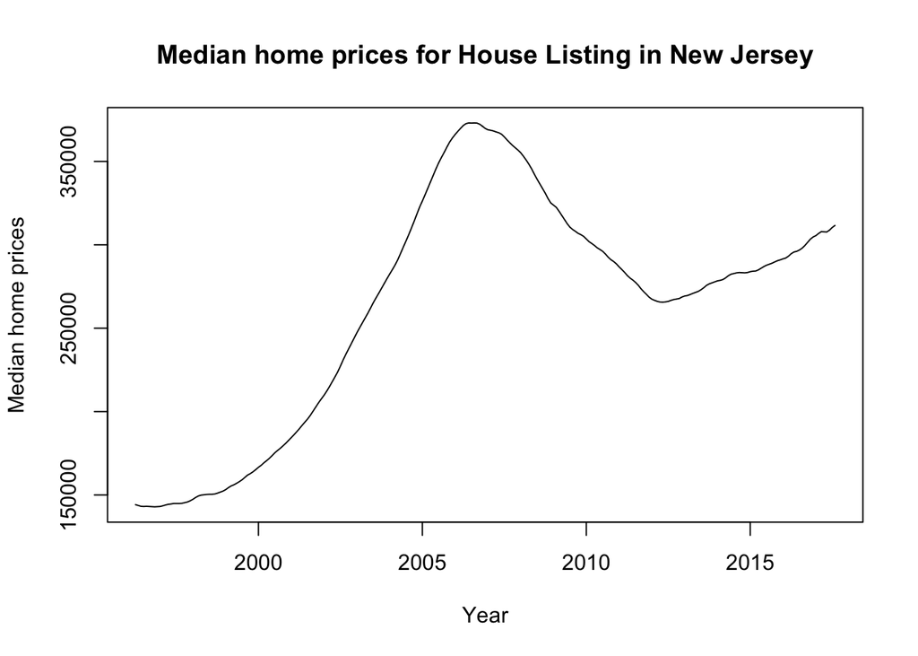

```r
plot(NJ_Home_TS, main = 'Median home prices for House Listing in New Jersey', xlab = 'Year', ylab = 'Median home prices')
```

##### Q: Please summaries your observations of the times series plot

- The plot shows that there is an increasing trend in the median home prices starting from 1996 till around 2006.
- From 2006 till 2012, there has been a decreasing trend in the home prices.
- From 2012, there has been steady increasing trend till the year 2017.
- The data however doesn’t appear to show any seasonal variation.
- If we were to forecast the data, we should be considering the window from 2012 to 2017.

## Central Tendency

##### Q: What are the min, max, mean, median, 1st and 3rd Quartile values of the times series?

```r
summary(NJ_Home_TS)
```

```
##    Min. 1st Qu.  Median    Mean 3rd Qu.    Max.
##  142900  197800  280200  263499  307900  373100
```

- The summary function above gives the min, max, mean, median, 1st and 3rd Quartile values of the times series.

##### Q: Show the box plot.

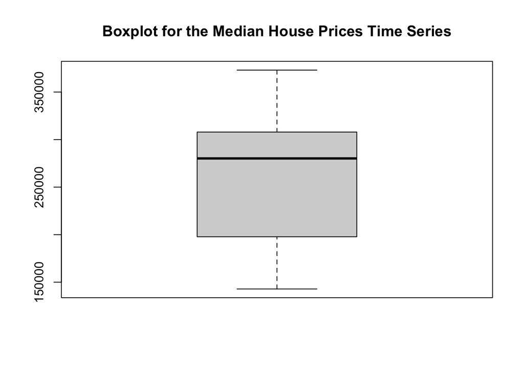

```r
boxplot(NJ_Home_TS, main = 'Boxplot for the Median House Prices Time Series')
```

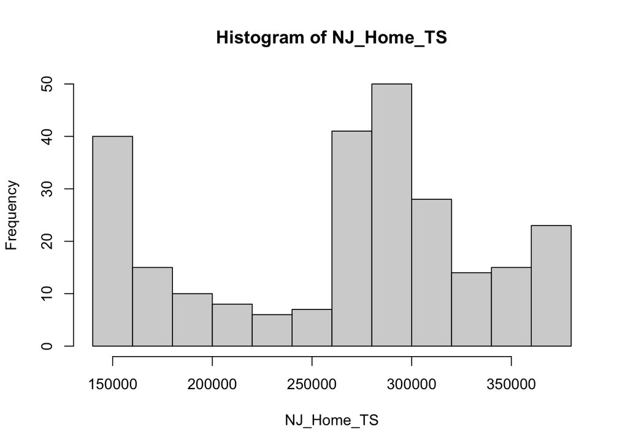

```r
hist(NJ_Home_TS)
```

##### Q: Can you summarize your observation about the time series from the summary stats and box plot?

- The boxplot shows that there are no outliers in the data.
- The Median is more towards the third quartile.
- From summary, we can also see that the median value is greater than the mean for the time series.
- This means that the data is left skewed. This can be justified seeing the histogram above as well.

## Decomposition

##### Plot the decomposition of the time series.

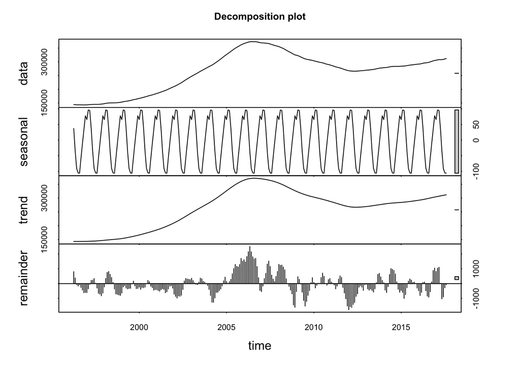

```r
stl_decomp <- stl(NJ_Home_TS,s.window ="periodic")
plot(stl_decomp, main = 'Decomposition plot')
```

##### Is the times series seasonal?

- No, the time series do not show any seasonal variation.

##### If seasonal, what are the values of the seasonal monthly indices?

##### For which month is the value of time series high and for which month is it low?

##### Can you think of the reason behind the value being high in those months and low in those months?

- The data set doesn’t have a seasonal variation. So the above three questions do not make sense for this time series.
- We can check this hypothesis in the coming question.

##### Show the plot for time series adjusted for seasonality. Overlay this with the line for actual time series? Does seasonality have big fluctuations to the value of time series?

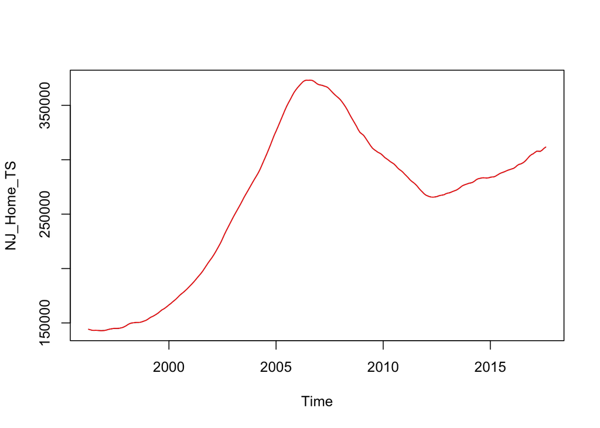

```r
plot(NJ_Home_TS)
lines(seasadj(stl_decomp), col="Red")
```

- As expected, the seasonal adjusted plot exactly overlapped with the actual data.
- This states that our hypothesis is true and there appears to not have any seasonality in this time series

## Naïve Method

##### Output

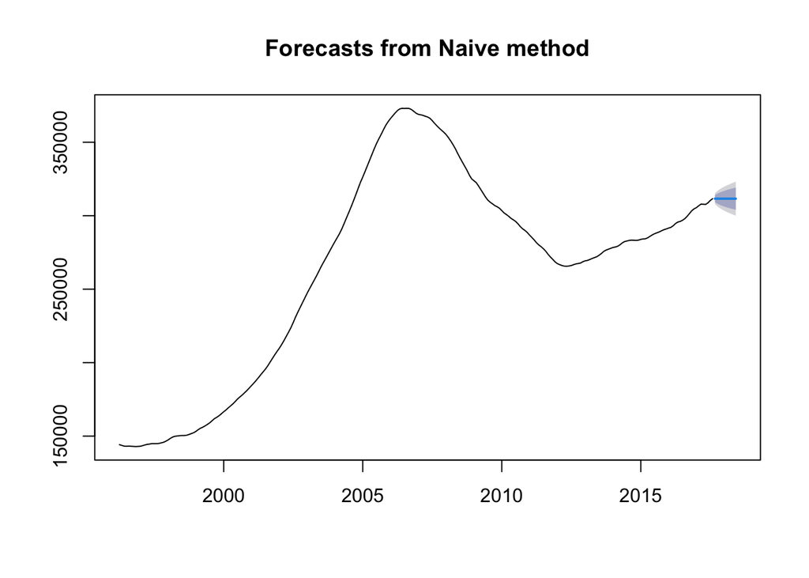

```r
naive_forecast = naive(NJ_Home_TS)
plot(naive_forecast)
```

##### Perform Residual Analysis for this technique.

###### Do a plot of residuals. What does the plot indicate?

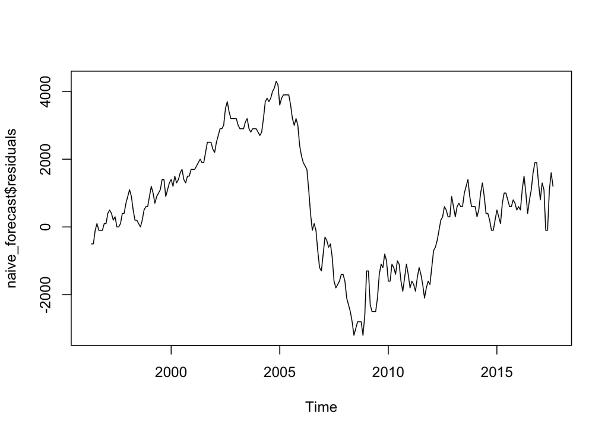

```r
plot(naive_forecast$residuals)
```

###### Do a Histogram plot of residuals. What does the plot indicate?

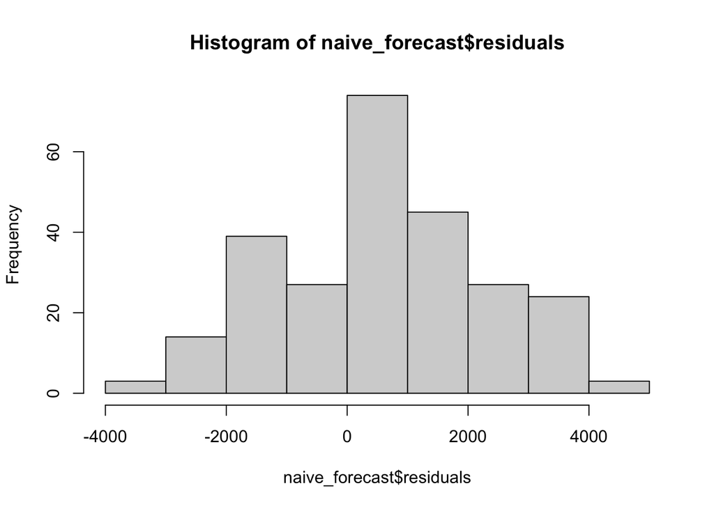

```r
hist(naive_forecast$residuals)
```

* The histogram appears to be normally distributed. * But the values do not have a mean zero. The histogram appears to be skewed on one side. * This means that the data is biased as the mean is not zero.

###### Do a plot of fitted values vs. residuals. What does the plot indicate?

###### Do a plot of actual values vs. residuals. What does the plot indicate?

###### Do an ACF plot of the residuals? What does this plot indicate?

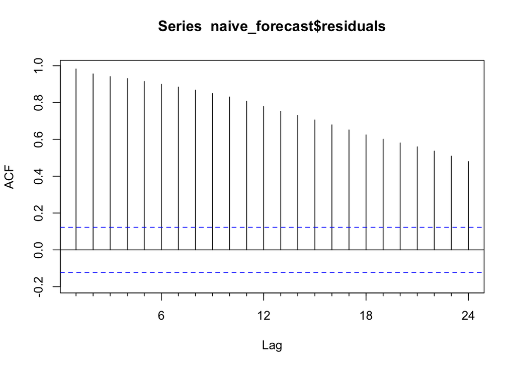

```r
Acf(naive_forecast$residuals)
```

- All the values of the Acf lot have crossed the confidence interval.
- Meaning that naive forecast is missing some main variables which we have missed our consideration for the forecast.

##### Print the 5 measures of accuracy for this forecasting technique

```r
accuracy(naive_forecast)
```

```
##                    ME     RMSE      MAE      MPE      MAPE       MASE      ACF1
## Training set 653.9062 1863.737 1508.594 0.298545 0.5737501 0.08272465 0.9823793
```

##### Forecast

###### Time series value for next year. Show table and plot

```r
forecast(naive_forecast)
```

```
##          Point Forecast    Lo 80    Hi 80    Lo 95    Hi 95
## Sep 2017         311600 309211.5 313988.5 307947.1 315252.9
## Oct 2017         311600 308222.2 314977.8 306434.1 316765.9
## Nov 2017         311600 307463.0 315737.0 305273.1 317926.9
## Dec 2017         311600 306823.0 316377.0 304294.3 318905.7
## Jan 2018         311600 306259.2 316940.8 303432.0 319768.0
## Feb 2018         311600 305749.5 317450.5 302652.4 320547.6
## Mar 2018         311600 305280.7 317919.3 301935.4 321264.6
## Apr 2018         311600 304844.4 318355.6 301268.2 321931.8
## May 2018         311600 304434.6 318765.4 300641.4 322558.6
## Jun 2018         311600 304047.0 319153.0 300048.7 323151.3
```

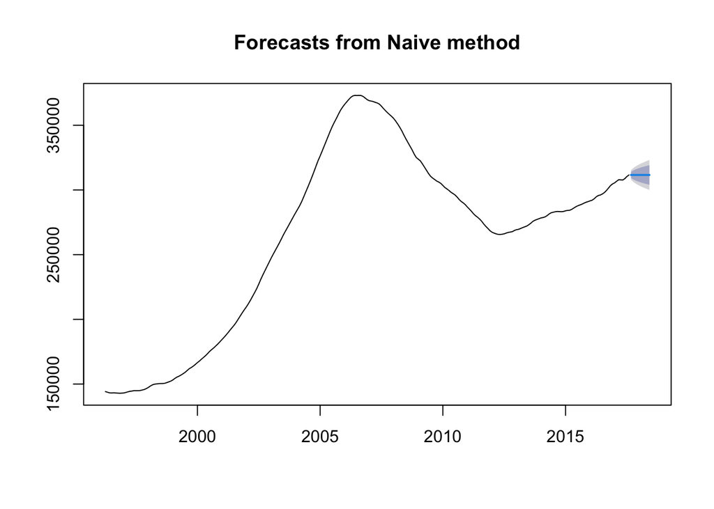

```r
plot(forecast(naive_forecast))
```

##### Summarize this forecasting technique

###### How good is the accuracy?

- The ME, RMSE values are very high indicating that this method may not be the right one to go with.
- We can consider more forecasting techniques and check if the error values are less than this one.

###### What does it predict the value of time series will be in one year?

- Based on naive forecast, the predicted value of the time series in one year is 311600.

###### Other observation

- From 2013 to 2017 there is observed to be an increasing trend in the data. So, naive forecast may not be a right way to forecast.
- Rather, we can try naive method with drift component and that may yield us better forecast.

## Simple Moving Averages

##### Plot the graph for time series.

##### Show the Simple Moving average of order 3 on the plot above in Red

##### Show the Simple Moving average of order 6 on the plot above in Blue

##### Show the Simple Moving average of order 9 on the plot above in Green

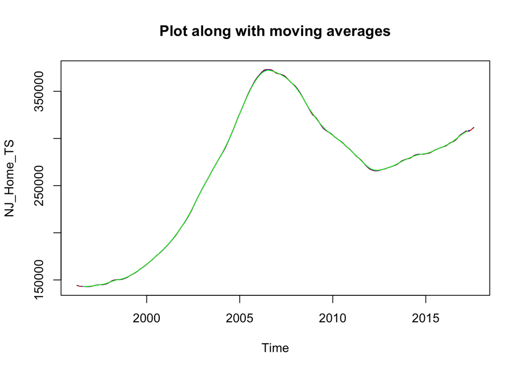

```r
mavg3_forecast = ma(NJ_Home_TS,order=3)
mavg6_forecast = ma(NJ_Home_TS,order=6)
mavg9_forecast = ma(NJ_Home_TS,order=9)
plot(NJ_Home_TS, main = "Plot along with moving averages")
lines(mavg3_forecast, col="Red")
lines(mavg6_forecast, col="Blue")
lines(mavg9_forecast, col="Green")
```

##### (Bonus) show the forecast of next 12 months using one of the simple average order that you feel works best for time series

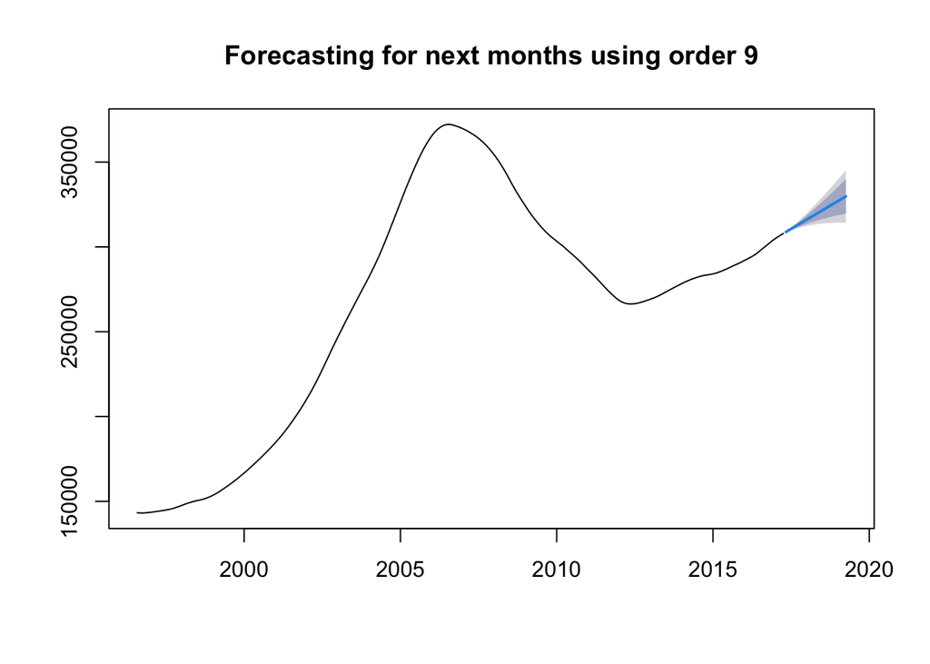

```r
plot(forecast(mavg9_forecast), main = "Forecasting for next months using order 9")
```

##### What are your observations of the plot as the moving average order goes up?

- From the plots, it is observed that the higher the order we consider, the smoother the moviing average curve in the plot.
- It can be seen that the Green line above is the smoothest compared to Blue or Red lines.

## Simple Smoothing

##### Perform a simple smoothing forecast for next 12 months for the time series.

###### What is the value of alpha? What does that value signify?

###### What is the value of initial state?

###### What is the value of sigma? What does the sigma signify?

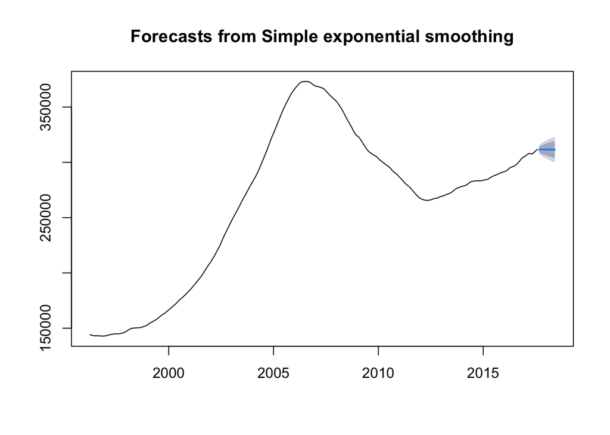

```r
ses_data <- ses(NJ_Home_TS)
plot(ses_data)
```

```r
attributes(ses_data)
```

```
## $names
##  [1] "model"     "mean"      "level"     "x"         "upper"     "lower"
##  [7] "fitted"    "method"    "series"    "residuals"
##
## $class
## [1] "forecast"
```

##### Perform Residual Analysis for this technique.

###### Do a plot of residuals. What does the plot indicate?

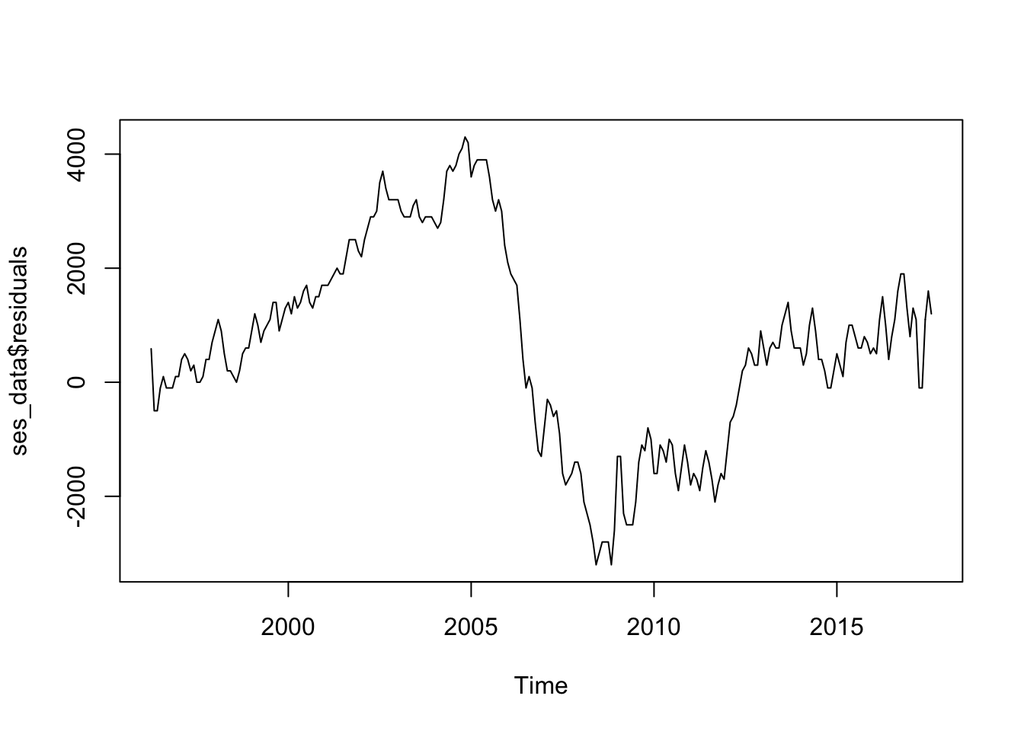

```r
plot(ses_data$residuals)
```

- The residuals appear to have increasing positive values and then peaked in the year 2005 and then dipped and went on to be negative.
- The residuals had a negative peak in the year between 2008 - 2009 and then slowly evened out from the year 2013.

###### Do a Histogram plot of residuals. What does the plot indicate?

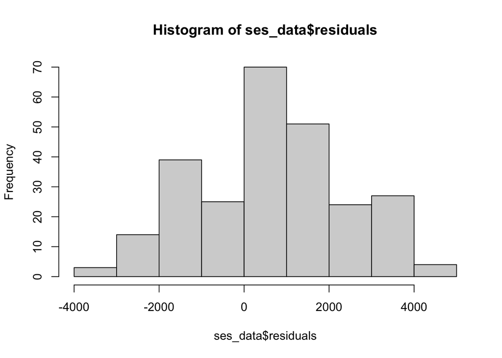

```r
hist(ses_data$residuals)
```

* The histogram appears to be normally distributed. * But the values do not have a mean zero. The histogram appears to be skewed on one side. * If the residual histogram doesnot have the mean to be zero, it means the data is biased.

###### Do a plot of fitted values vs. residuals. What does the plot indicate?

###### Do a plot of actual values vs. residuals. What does the plot indicate?

###### Do an ACF plot of the residuals? What does this plot indicate?

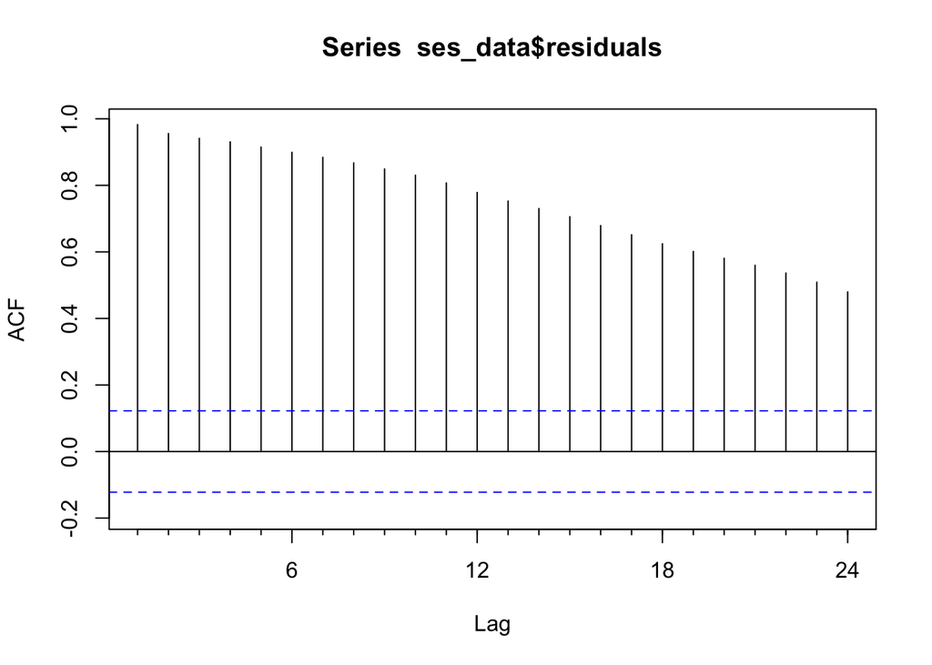

```r
Acf(ses_data$residuals)
```

- All the values of the Acf lot have crossed the confidence interval.
- Meaning that simple smoothing forecast is missing some main variables which we have missed our consideration for the forecast.

##### Print the 5 measures of accuracy for this forecasting technique

```r
accuracy(ses_data)
```

```
##                    ME     RMSE      MAE       MPE      MAPE      MASE      ACF1
## Training set 653.7106 1860.651 1505.155 0.2989964 0.5731573 0.0825361 0.9824752
```

##### Forecast

###### Time series value for next year. Show table and plot

```r
forecast(ses_data)
```

```
##          Point Forecast    Lo 80    Hi 80    Lo 95    Hi 95
## Sep 2017       311599.9 309206.0 313993.7 307938.8 315261.0
## Oct 2017       311599.9 308214.6 314985.1 306422.6 316777.2
## Nov 2017       311599.9 307453.9 315745.9 305259.1 317940.6
## Dec 2017       311599.9 306812.5 316387.2 304278.3 318921.5
## Jan 2018       311599.9 306247.5 316952.3 303414.1 319785.7
## Feb 2018       311599.9 305736.7 317463.1 302632.8 320566.9
## Mar 2018       311599.9 305266.9 317932.9 301914.4 321285.4
## Apr 2018       311599.9 304829.6 318370.1 301245.7 321954.1
## May 2018       311599.9 304419.0 318780.8 300617.6 322582.1
## Jun 2018       311599.9 304030.5 319169.2 300023.6 323176.2
```

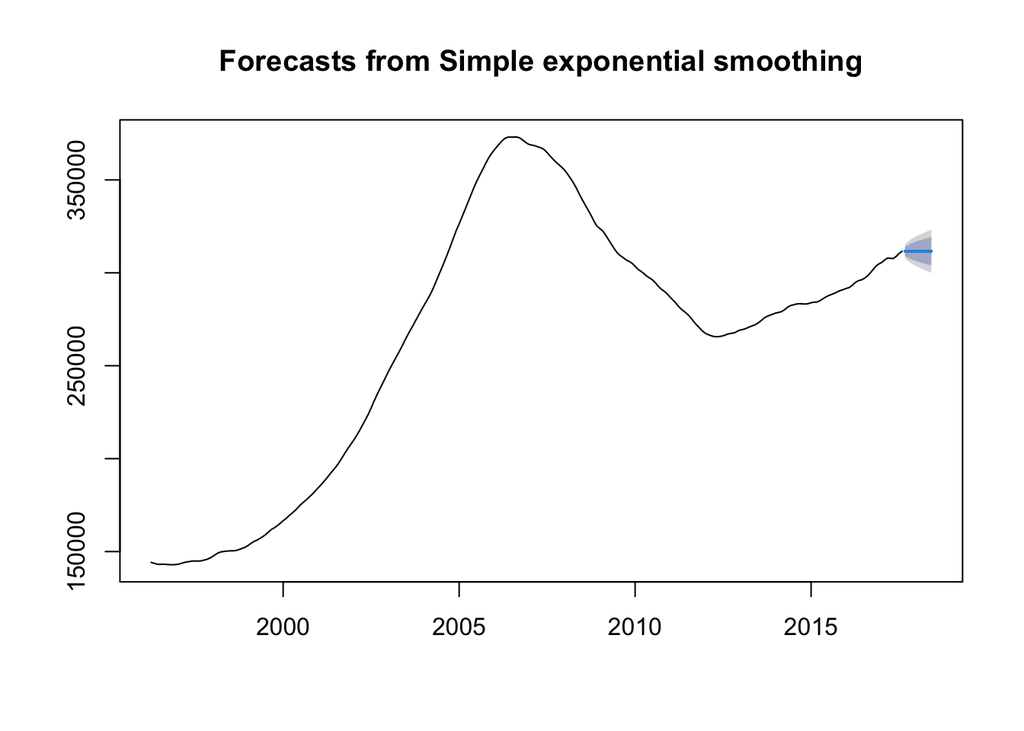

```r
plot(forecast(ses_data))
```

##### Summarize this forecasting technique

###### How good is the accuracy?

- The ME, RMSE values are very high indicating that this method may not be the right one to go with.
- We can consider more forecasting techniques and check if the error values are less than this one.

###### What does it predict the value of time series will be in one year?

- Based on simple smoothing forecast, the predicted value of the time series in one year is 311599.9.

###### Other observation

- From 2013 to 2017 there is observed to be an increasing trend in the data. So, this forecast may not be a right way to forecast.
- We need to try other forecasting methods and check the accuracies in each case.

## Holt-Winters

##### Perform Holt-Winters forecast for next 12 months for the time series.

```r
HW_forecast = HoltWinters(NJ_Home_TS)
```

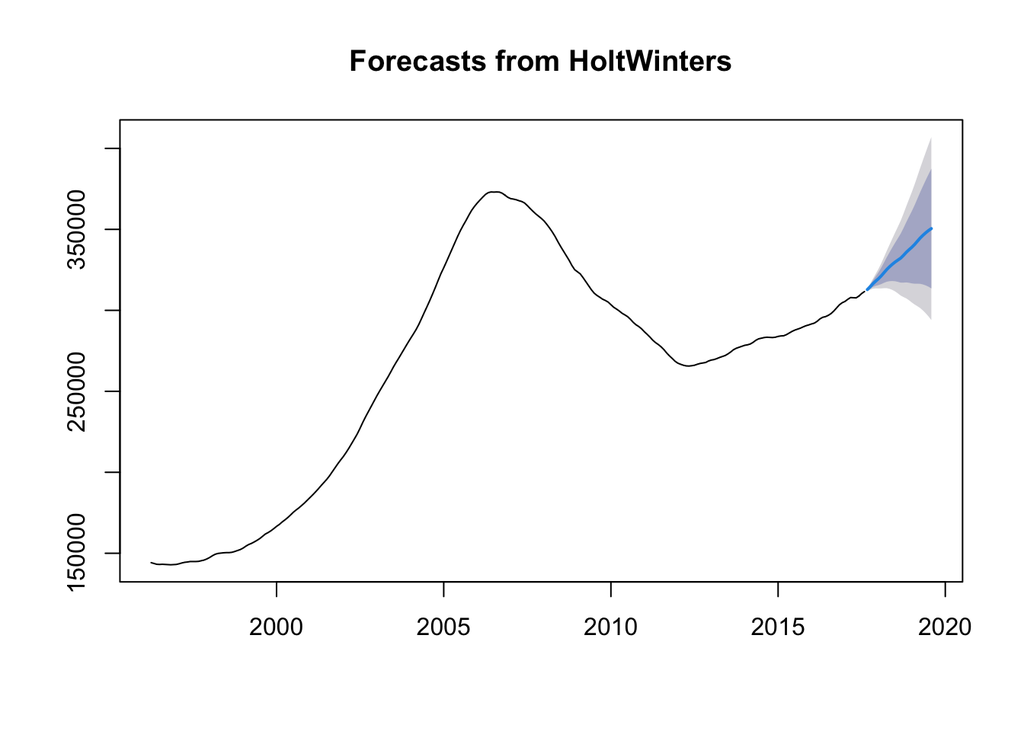

```r
plot(forecast(HW_forecast))
```

```r
hw <- forecast(HW_forecast)
```

###### What is the value of alpha? What does that value signify?

```r
HW_forecast$alpha
```

```
##     alpha
## 0.9741216
```

- Alpha specifies the coefficient for the level smoothing in Holtwinters.
- Values near 1.0 mean that the latest value has more weight.

###### What is the value of beta? What does that value signify?

```r
HW_forecast$beta
```

```
## beta
##    1
```

- Beta specifies the coefficient for the trend smoothing in Holtwinters.
- Values 1.0 means that the latest value has highest weight

###### What is the value of gamma? What does that value signify?

```r
HW_forecast$gamma
```

```
## gamma
##     1
```

- Gamma specifies the coefficient for the seasonal smoothing in Holtwinters.
- Values 1.0 means that the latest value has highest weight.

###### What is the value of initial states for the level, trend and seasonality? What do these values signify?

###### What is the value of sigma? What does the sigma signify?

##### Perform Residual Analysis for this technique.

###### Do a plot of residuals. What does the plot indicate?

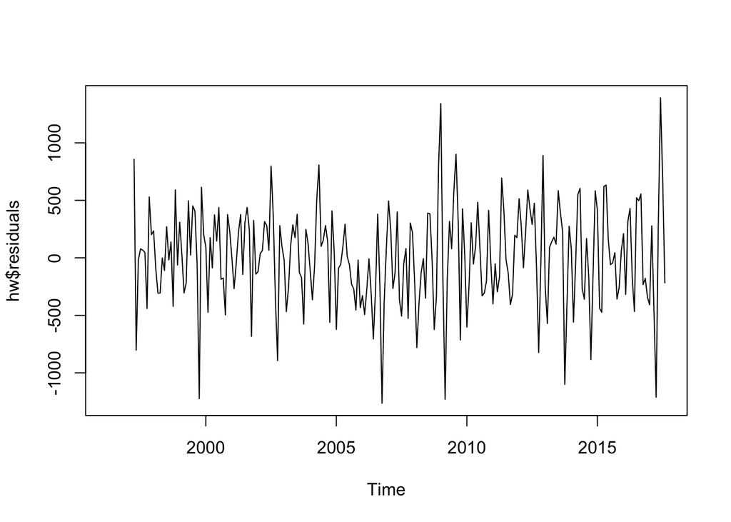

```r
plot(hw$residuals)
```

- The residuals appear to be random and also the mean looks to be near zero. We can check this with histogram.
- We can observe a couple of up and downs in 2009 and 2017. But even they did not show and growing residual pattern.

###### Do a Histogram plot of residuals. What does the plot indicate?

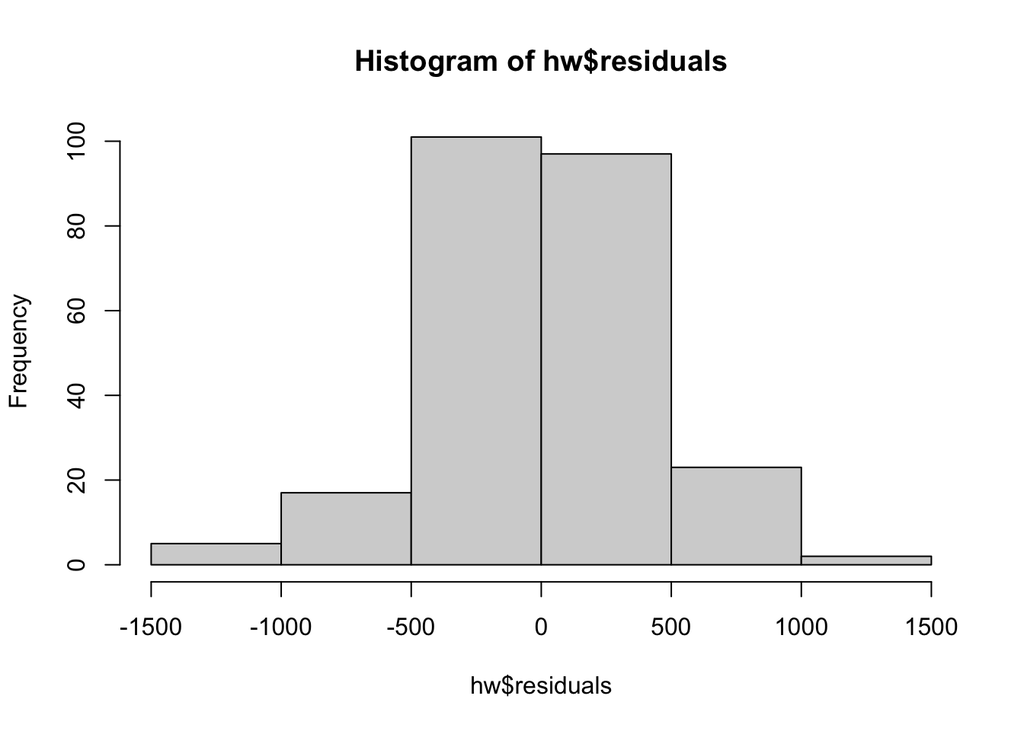

```r
hist(hw$residuals)
```

* The histogram appears to be normally distributed. * And the mean is near zero. Indicating the data is not biased. * Overall, comparing the previous forecasts, this forecast appears to be the best till now.

###### Do a plot of fitted values vs. residuals. What does the plot indicate?

###### Do a plot of actual values vs. residuals. What does the plot indicate?

###### Do an ACF plot of the residuals? What does this plot indicate?

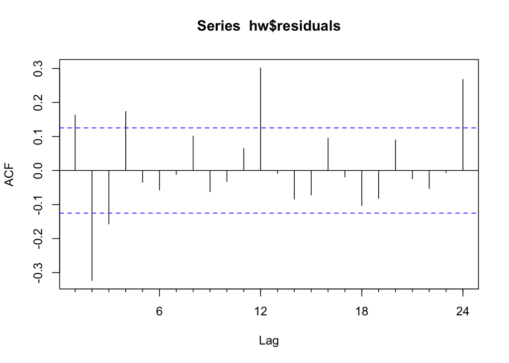

```r
Acf(hw$residuals)
```

- Quite a few values of the Acf lot have crossed the confidence interval.
- The Acf crossed the confidence interval at 1, 2, 3, 4, 12, 24 lags.
- Which states that there are still few variables which we have missed in our forecast and that our forecast can still be improved.

##### Print the 5 measures of accuracy for this forecasting technique

```r
accuracy(hw)
```

```
##                    ME     RMSE      MAE         MPE      MAPE       MASE
## Training set 5.905251 422.1518 330.2261 0.006674805 0.1291776 0.01810815
##                   ACF1
## Training set 0.1634457
```

##### Forecast

###### Time series value for next year. Show table and plot

```r
forecast(HW_forecast)
```

```
##          Point Forecast    Lo 80    Hi 80    Lo 95    Hi 95
## Sep 2017       312788.0 312245.9 313330.0 311959.0 313617.0
## Oct 2017       314497.4 313310.3 315684.4 312681.9 316312.8
## Nov 2017       316379.8 314400.3 318359.4 313352.4 319407.3
## Dec 2017       317994.8 315100.0 320889.6 313567.7 322422.0
## Jan 2018       319507.1 315589.2 323425.1 313515.2 325499.1
## Feb 2018       321248.7 316210.0 326287.3 313542.7 328954.6
## Mar 2018       323244.1 316995.1 329493.1 313687.1 332801.1
## Apr 2018       325220.5 317677.6 332763.3 313684.7 336756.3
## May 2018       326920.0 318004.9 335835.1 313285.5 340554.5
## Jun 2018       328464.1 318102.6 338825.6 312617.5 344310.7
## Jul 2018       329851.8 317973.3 341730.3 311685.2 348018.4
## Aug 2018       331051.8 317589.0 344514.7 310462.1 351641.5
## Sep 2018       332239.8 317121.5 347358.1 309118.4 355361.3
## Oct 2018       333949.2 317120.3 350778.1 308211.6 359686.8
## Nov 2018       335831.7 317232.0 354431.3 307386.0 364277.4
## Dec 2018       337446.6 317018.1 357875.2 306203.9 368689.4
## Jan 2019       338959.0 316645.2 361272.7 304833.0 373085.0
## Feb 2019       340700.5 316446.8 364954.2 303607.6 377793.4
## Mar 2019       342695.9 316449.1 368942.8 302554.8 382837.1
## Apr 2019       344672.3 316380.5 372964.1 301403.7 387940.9
## May 2019       346371.8 315984.5 376759.1 299898.5 392845.2
## Jun 2019       347915.9 315383.8 380448.0 298162.4 397669.5
## Jul 2019       349303.7 314578.6 384028.8 296196.2 402411.2
## Aug 2019       350503.7 313538.3 387469.0 293970.1 407037.3
```

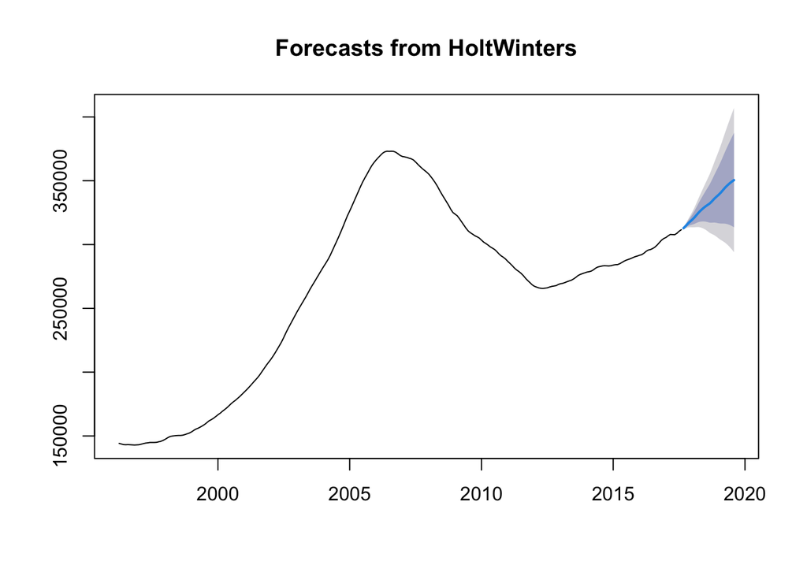

```r
plot(forecast(HW_forecast))
```

##### Summarize this forecasting technique

###### How good is the accuracy?

- The ME, RMSE values are quite low compared to any of our previous forecasts.
- Holwinters is a better forecast compared to naive and simple smoothing.

###### What does it predict the value of time series will be in one year?

- Based on HoltWinters forecast, the predicted value of the time series in one year is 331051.8.

###### Other observation

- Holtwinters appears to be the best forecast considering all the previous forecast methods.
- However, this forecast can still be improved as we can see that the residuals have crossed the confidence interval in the Acf plot.

## Accuracy Summary

##### Show a table of all the forecast method above with their accuracy measures.

```r
accuracy(naive_forecast)
```

```
##                    ME     RMSE      MAE      MPE      MAPE       MASE      ACF1
## Training set 653.9062 1863.737 1508.594 0.298545 0.5737501 0.08272465 0.9823793
```

```r
accuracy(ses_data)
```

```
##                    ME     RMSE      MAE       MPE      MAPE      MASE      ACF1
## Training set 653.7106 1860.651 1505.155 0.2989964 0.5731573 0.0825361 0.9824752
```

```r
accuracy(hw)
```

```
##                    ME     RMSE      MAE         MPE      MAPE       MASE
## Training set 5.905251 422.1518 330.2261 0.006674805 0.1291776 0.01810815
##                   ACF1
## Training set 0.1634457
```

##### Show the best and worst forecast method for the accuracy measure of your choice. Why did you choose that accuracy measure?

- To start with, there is nothing like best or worst forecast.
- Considering the accuracy data above, HoltWinters forecast seems to fit the time series the best as it has the least error values.
- And naive forecast seems to be the worst as it has the largest ME and RMSE values.

## Conclusion

##### Summarize your analysis of time series value over the time-period.

- Upon initial observation, the data looked to have only trend and did not appear to show any seasonal variation.
- We have checked the hypothesis and have observed that there is no seasonal variation in the time series.
- Based on the three forecasting methods naive, simple smoothing, and HoltWinters, we can see that HoltWinters forecast provides to be the better forecasting method in this case.
- This is because the forecast fits perfectly and also the error values are quiet low for HoltWinters forecast.

##### Based on your analysis and forecast above, do you think the value of the time series will increase, decrease or stay flat over the next year? How about next 2 years?

- Based on the analysis and forecast, the time series will increase over the next year and the next 2 years.